# **Problem Statement**

#### **Question 8** : finalize appropriate number of clusters by checking the silhoutte score as well. Is the answer different from the elbow plot?

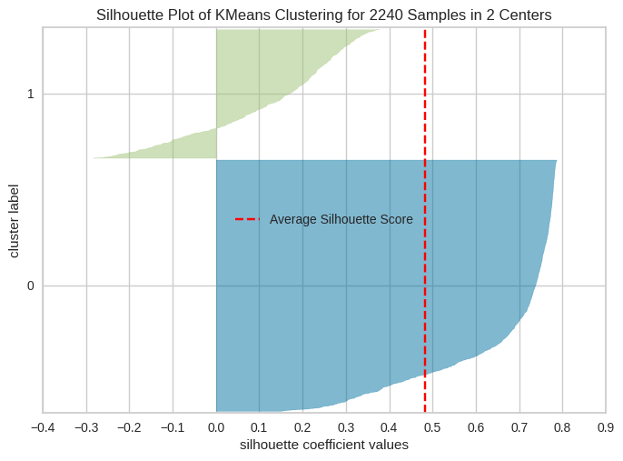

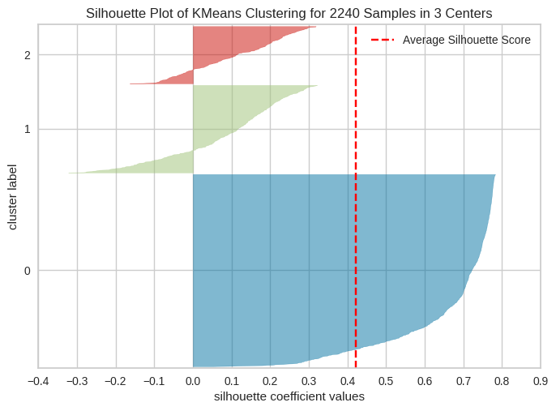

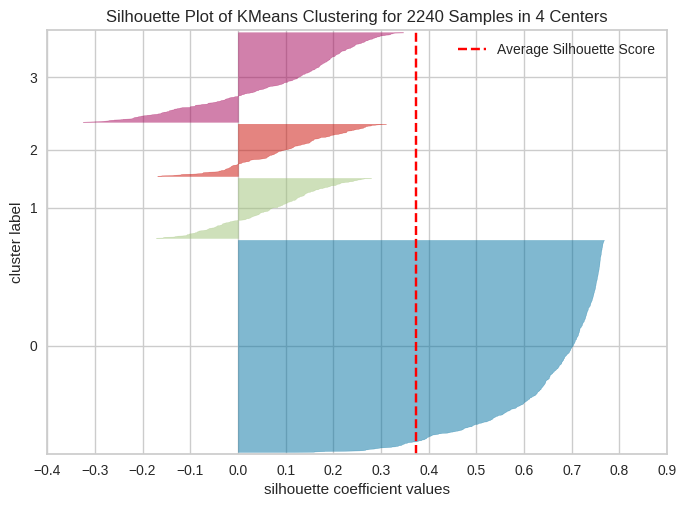

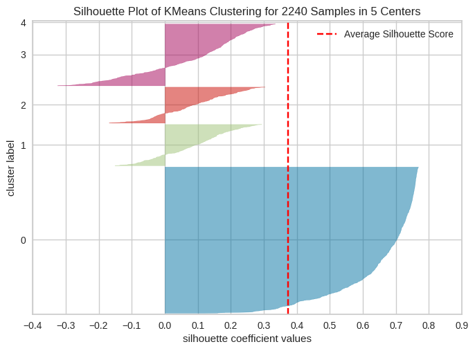

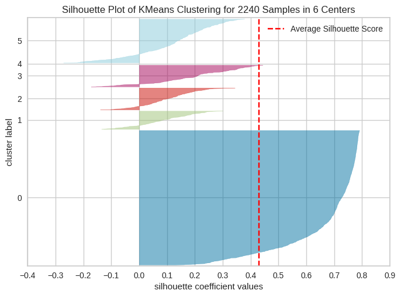

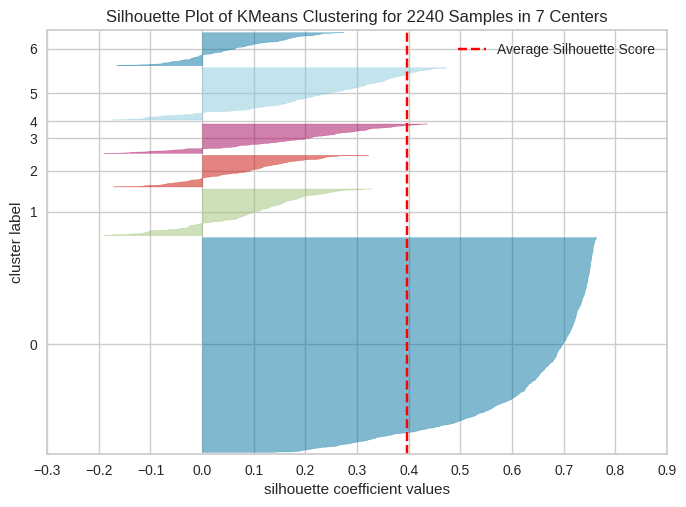

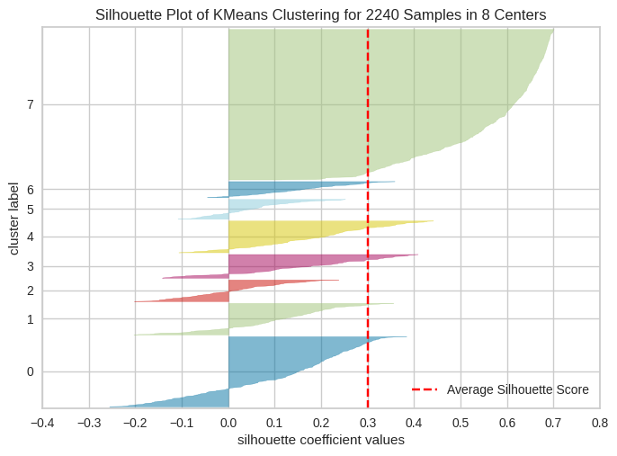

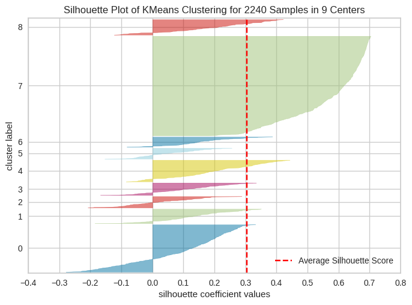

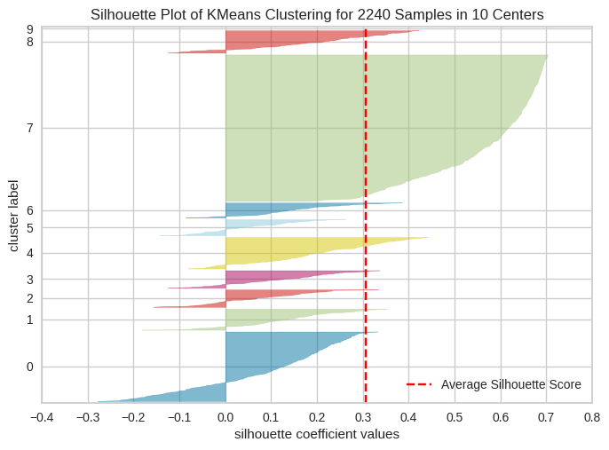

```python
# Write your code here
for i in range(2, 11):
    # Instantiate the K-Means model and the SilhouetteVisualizer
    model = KMeans(n_clusters=i, random_state=42)
    visualizer = SilhouetteVisualizer(model, colors='yellowbrick')

    # Fit the data to the visualizer
    visualizer.fit(scaled_features)

    # Finalize and render the figure
    visualizer.show()
```

##### **Observations:**

#### **Question 9**: Do a final fit with the appropriate number of clusters. How much total time does it take for the model to fit the data?

```python
# Write your code here
from time import time

t1 = time()
kmeans = KMeans(n_clusters=4, random_state=42)
kmeans.fit(scaled_features)
t2 = time()
print(f"time taken: {t2-t1}")
```

```
time taken: 0.011031150817871094
```

##### **Observations:**

## **Cluster Profiling and Comparison**

#### **Question 10**: Perform cluster profiling using boxplots for the K-Means algorithm. Analyze key characteristics of each cluster and provide detailed observations.

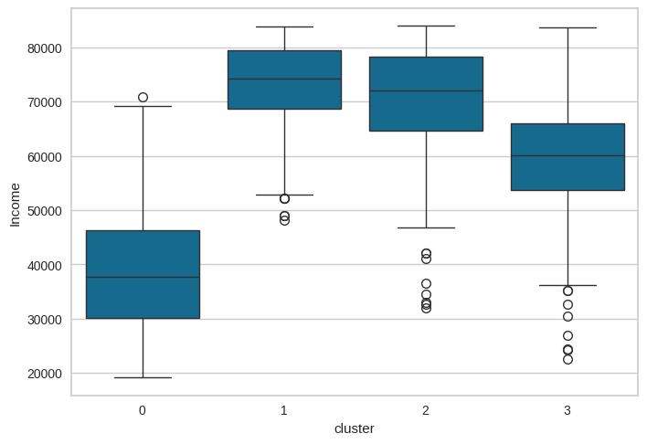

```python
# Write your code here
data['cluster'] = kmeans.labels_

# Filter out outliers
q_low = data['Income'].quantile(0.05)
q_hi  = data['Income'].quantile(0.95)

filtered_data = data[(data['Income'] < q_hi) & (data['Income'] > q_low)]

sns.boxplot(data=filtered_data, x='cluster', y='Income')
```

Cluster 1 has a relatively tight distribution, suggesting that it's a consistently high income group.

Cluster 0 has the lowest median income with around 38k.

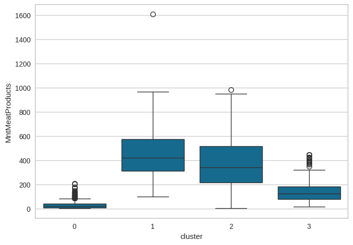

```python
sns.boxplot(data=filtered_data, x='cluster', y='MntMeatProducts')
```

Cluster 1 spends most of their money on meat products with Cluster 2 following.

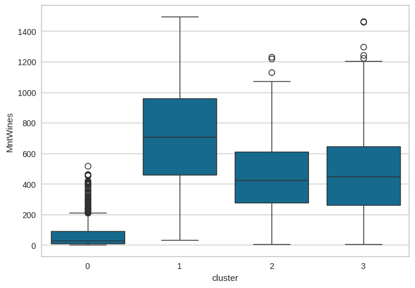

```python
sns.boxplot(data=filtered_data, x='cluster', y='MntWines')
```

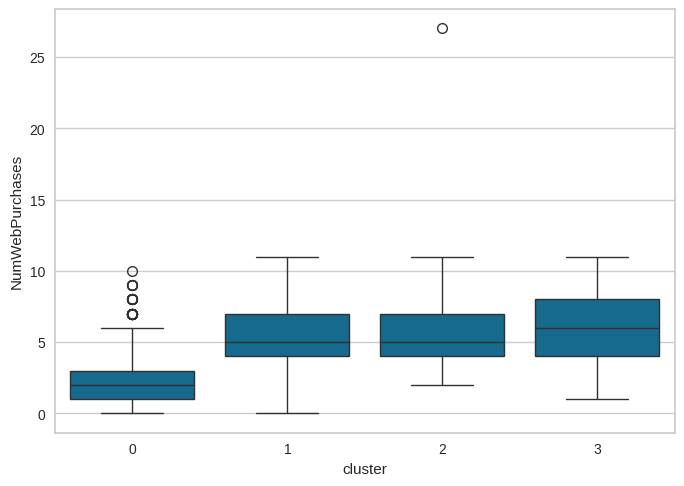

```python
sns.boxplot(data=filtered_data, x='cluster', y='NumWebPurchases')
```

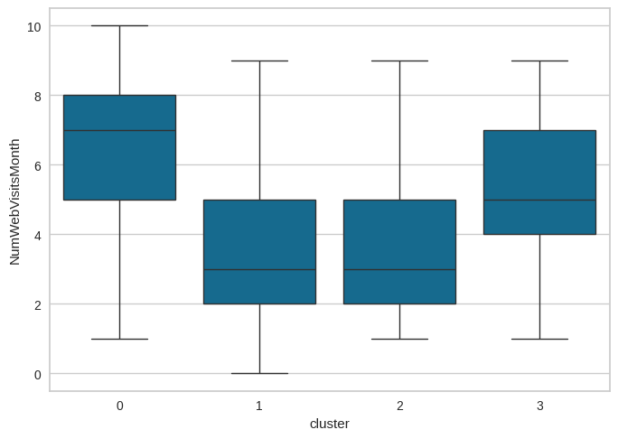

```python
sns.boxplot(data=filtered_data, x='cluster', y='NumWebVisitsMonth')
```

Cluster 0 has the highest amount of web visits in the last month with a median of around 7. This suggest that there is room for opportunity to convert those visits into purchases.

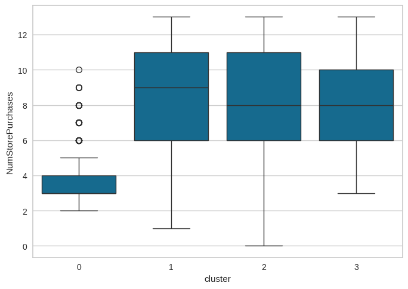

```python
sns.boxplot(data=filtered_data, x='cluster', y='NumStorePurchases')
```

Cluster 1 has the highest amount of in store purchases

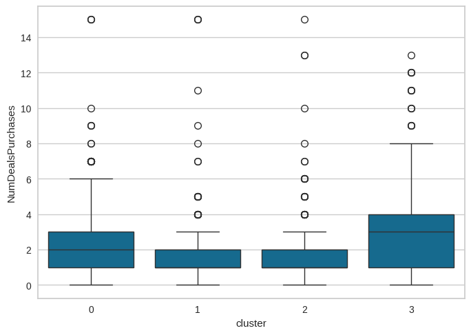

```python
sns.boxplot(data=data, x='cluster', y='NumDealsPurchases')
```

The highest success rate for offers are within cluster 3. This could explain why they are more responsive to deals and discounts. Recommend sending them more promotional offers and discounts to encourage them to make a purchase.

##### **Observations:**

#### **Question 11**: Perform cluster profiling on the data using a barplot for the K-Means algorithm. Provide insights and key observations for each cluster based on the visual analysis.

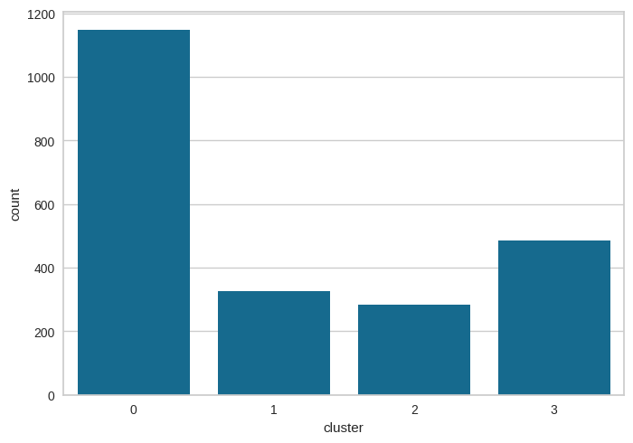

```python
# Write your code her
sns.countplot(data=data, x='cluster')
```

There are 1000+ customers in Cluster 0 but they represent some of the lowest incomes and spends.

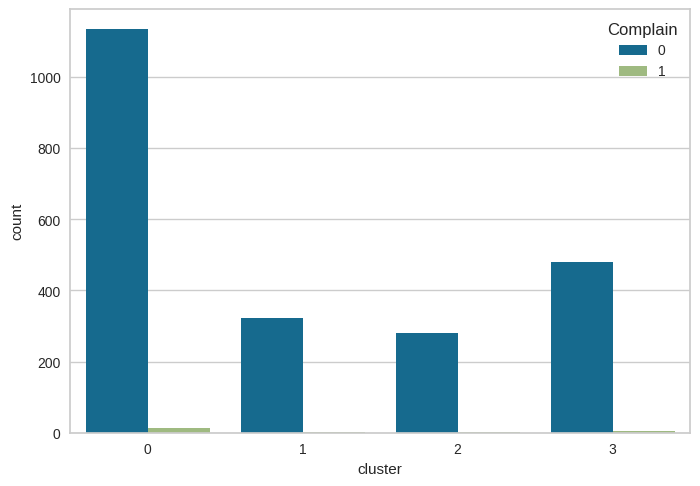

```python
sns.countplot(data=data, x='cluster', hue='Complain')
```

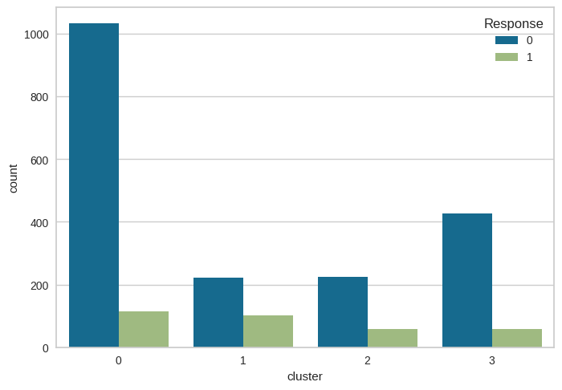

```python
sns.countplot(data=data, x='cluster', hue='Response')
```

##### **Observations:**

## **Business Recommedations**

#### **Question 12**: Based on the cluster insights, what business recommendations can be provided?

Based on the insights, there are 4 customer segments in the provided data. For security purposes we have aggregated the data. In our analysis we found that the highest value customers are within clusters 1 and 2 since they have the highest median incomes of 75k and 72k respectfully. Cluster 1 has a relatively tight distribution, suggesting that it's a consistently high income group. Cluster 0 has the lowest median income with around 38k. Clusters 1 and 2 spend mostly on luxury items within the meat and wines categories.

The first recommendation to foster growth is to run targeted campaigns towards our high value customers to increase Life Time Value. We should create exclusive offers in the meat and wine segments through in store tastings or loyalty programs. Also, build a recommendation system to pair their frequent purchases with items that go well with them. Lastly, we could offer in store promotions since they also represent a large majority of in store purchasing.

Cluster 3 represents budget conscious customers that respond to discounts and promotions. We can offer them coupons, discounts and bundle deals while highlighting the value of our products to encourage them to make quality buys within their budget.

Cluster 0 has the highest amount of online traffic but the lowest conversion rate to a purchase. It's worth revising the user journey on the web application to identify pain points. Also, making a reminder system to customers can revisit and potentially incentivize their purchase.